# Classifying risk for loan

```python
# import required libraries
import numpy as np
import pandas as pd
import gc
from PIL import Image
import itertools
import pprint
import random

from sklearn.preprocessing import LabelEncoder, Imputer, MinMaxScaler
from sklearn.decomposition import PCA
from sklearn.metrics import accuracy_score, recall_score, classification_report, roc_curve, auc, roc_auc_score
from sklearn.model_selection import train_test_split, KFold
from sklearn.linear_model import LogisticRegression
from sklearn.ensemble import RandomForestClassifier, GradientBoostingClassifier
from sklearn.tree import DecisionTreeClassifier
from sklearn.naive_bayes import GaussianNB
from sklearn.model_selection import GridSearchCV
from xgboost import XGBClassifier
import lightgbm as lgb
from lightgbm import LGBMClassifier

import seaborn as sns
import matplotlib.pyplot as plt
%matplotlib inline

# Suppress warnings
import warnings
warnings.filterwarnings('ignore')
```

# Business understanding

In finance, a loan is the lending of money by one or more individuals, organizations or other entities to other individuals, organizations etc. The recipient (i.e. the borrower) incurs a debt, and is usually liable to pay interest on that debt until it is repaid, and also to repay the principal amount borrowed.

A loan in time enables the borrower to meet financial goals. At the same time, the interest associated with the loan generates revenues for the lender.

However, there is always a risk associated with lending, especially in case of customers having insufficient or non-existent credit histories. If the borrower defaults a loan, then that loan becomes non-performing asset (or, NPA) for the lender. Any NPA hits the bottom-line of the lending organization.

Therefore, every lending organization strives to assess the risk associated with the loan. Primarily, they want to assess their clients' repayment abilities well in advance before deciding on approval and disbursement of loans. Objective of this project is to build a loan default risk classifier. The classifier will be supervised classifier who can be trained on historical data, and classify a new loan accordingly.

Home Credit maintains all historical records related to loan applications. Objective of this project is to build a classifier that, depending on the loan application, can predict whether an applicant will be able to repay the loan or not. This classifier will help bank to approve or reject a loan application efficiently.

# Data Understanding

In this project, we shall use loan application data provided by [Home Credit Group](http://www.homecredit.net/).

This project will build a supervised binary classifier which will predict as follows:

- Output label as '0': will repay loan on time
- Output label as '1': will have difficulty in repaying loan or will default

Following data will be used:

- **loan_applications.csv**: CSV containing data on loan applications. Each row in this CSV represents one loan.
- **loan_applications_columns_description.csv**: This file contains descriptions for the columns of loan applications data

# Part 1 - Load data

- Application data is present in **loan_applications.csv**
- Description of columns is present in **loan_applications_columns_description.csv**

```python
# read description
data_col_desc_df = pd.read_csv('data/loan_applications_columns_description.csv', encoding = 'ISO-8859-1')
del data_col_desc_df['Unnamed: 0']
data_col_desc_df.head(5)
```

|  | Table | Row | Description | Special |
| --- | --- | --- | --- | --- |
| 0 | loan_applications | SK_ID_CURR | ID of loan in our sample | NaN |
| 1 | loan_applications | TARGET | Target variable (1 - client with payment diffi... | NaN |
| 2 | loan_applications | NAME_CONTRACT_TYPE | Identification if loan is cash or revolving | NaN |
| 3 | loan_applications | CODE_GENDER | Gender of the client | NaN |
| 4 | loan_applications | FLAG_OWN_CAR | Flag if the client owns a car | NaN |

Load the data and examine few rows.

```python
# application data
app_data = pd.read_csv('data/loan_applications.csv')
app_data.head()
```

|  | SK_ID_CURR | TARGET | NAME_CONTRACT_TYPE | CODE_GENDER | FLAG_OWN_CAR | FLAG_OWN_REALTY | CNT_CHILDREN | AMT_INCOME_TOTAL | AMT_CREDIT | AMT_ANNUITY | ... | FLAG_DOCUMENT_18 | FLAG_DOCUMENT_19 | FLAG_DOCUMENT_20 | FLAG_DOCUMENT_21 | AMT_REQ_CREDIT_BUREAU_HOUR | AMT_REQ_CREDIT_BUREAU_DAY | AMT_REQ_CREDIT_BUREAU_WEEK | AMT_REQ_CREDIT_BUREAU_MON | AMT_REQ_CREDIT_BUREAU_QRT | AMT_REQ_CREDIT_BUREAU_YEAR |
| --- | --- | --- | --- | --- | --- | --- | --- | --- | --- | --- | --- | --- | --- | --- | --- | --- | --- | --- | --- | --- | --- |
| 0 | 100002 | 1 | Cash loans | M | N | Y | 0 | 202500.0 | 406597.5 | 24700.5 | ... | 0 | 0 | 0 | 0 | 0.0 | 0.0 | 0.0 | 0.0 | 0.0 | 1.0 |
| 1 | 100003 | 0 | Cash loans | F | N | N | 0 | 270000.0 | 1293502.5 | 35698.5 | ... | 0 | 0 | 0 | 0 | 0.0 | 0.0 | 0.0 | 0.0 | 0.0 | 0.0 |
| 2 | 100004 | 0 | Revolving loans | M | Y | Y | 0 | 67500.0 | 135000.0 | 6750.0 | ... | 0 | 0 | 0 | 0 | 0.0 | 0.0 | 0.0 | 0.0 | 0.0 | 0.0 |
| 3 | 100006 | 0 | Cash loans | F | N | Y | 0 | 135000.0 | 312682.5 | 29686.5 | ... | 0 | 0 | 0 | 0 | NaN | NaN | NaN | NaN | NaN | NaN |
| 4 | 100007 | 0 | Cash loans | M | N | Y | 0 | 121500.0 | 513000.0 | 21865.5 | ... | 0 | 0 | 0 | 0 | 0.0 | 0.0 | 0.0 | 0.0 | 0.0 | 0.0 |

5 rows × 122 columns

```python
print('Application data shape: ', app_data.shape)
```

```
Application data shape:  (307511, 122)
```

# Part 2 - Preprocessing

Let's check on following aspects:

1. Handling outliers
2. Analyze for missing values
3. Encoding categorical variables

## 2.1. Handle outliers

At first, let's build functions that will handle outliers for the columns.

```python
def handle_outliers(df, col_name, threshold_max, threshold_min = 0, value_to_be_replaced = np.nan):
    '''
    This function handles outliers for a column of the dataframe.
    Any value that is greater than threshold_max or less than threshold_min is considered as an outlier.
    All such outliers will be replaced with value_to_be_replaced
    INPUT:
    df - Dataframe for which outliers need to be handled
    col_name - column name for which outliers need to be handled
    threshold_max - Any value greater than this will be considered as an outlier
    threshold_min - Any value less than this will be considered as an outlier
    value_to_be_replaced - all outliers will be replaced by this value
    OUTPUT:
    df - dataframe after outliers are handled
    '''
    # any value above or below the threshold will be considered as outlier
    is_outlier = (df[col_name] > threshold_max) | (df[col_name] < threshold_min)
    df_anomalous = df[is_outlier]
    num_of_outlier_rows = len(df_anomalous.index)

    if num_of_outlier_rows > 0:
        # print all those unique outlier values
        outliers = df_anomalous[col_name].unique()
        print("List of unique outlier values in '{}' column, as found: {}".format(col_name, str(outliers)))

        # replace all outliers
        df.loc[is_outlier, col_name] = value_to_be_replaced
        print('Number of rows updated: ', str(num_of_outlier_rows))
    else:
        print("No outlier found for column '{}'.".format(col_name))

    del df_anomalous
    gc.collect()

    return df
```

```python
def select_data_by_values(df, col_name, valid_values):
    '''
    This function selects only those rows where value under col_name belongs to valid_values
    INPUT:
    df - Dataframe for which outliers need to be handled
    col_name - column name for which outliers need to be handled
    valid_values - list of valid values supported
    OUTPUT:
    df - dataframe after outliers are handled
    '''
    rows_before = len(df.index)
    df = df[df[col_name].isin(valid_values)]
    rows_after = len(df.index)

    # print some good messages
    rows_filtered = rows_before - rows_after
    if rows_filtered > 0:
        print('Number of rows excluded: ', str(rows_filtered))
    else:
        print("No outlier found for column '{}'.".format(col_name))

    return df
```

After closely inspecting 'loan_applications.csv', following columns will be checked further for any possible outlier value:

- DAYS_BIRTH
- DAYS_EMPLOYED
- OWN_CAR_AGE
- REGION_RATING_CLIENT_W_CITY
- REGION_RATING_CLIENT
- AMT_INCOME_TOTAL
- CODE_GENDER

Primarily, the check will be on invalid values. For example, age of a person asking for loan can't be more than 90 years, etc.

### DAYS_BIRTH

The numbers in the DAYS_BIRTH column are **negative** because they are recorded relative to the current loan application.  
Any negative value less than 90 years or more than 0 will be outlier.

```python
min_days_birth = -32850
max_days_birth = 0
```

```python
app_data = handle_outliers(app_data, 'DAYS_BIRTH', max_days_birth, min_days_birth)
```

```
No outlier found for column 'DAYS_BIRTH'.
```

### DAYS_EMPLOYED

Let's identify anomalous values in 'DAYS_EMPLOYED' column. 'DAYS_EMPLOYED' contains number of days relative to the application when a person was employed. So, values will be negative or zero. Postive value indicates future date and is an outlier.  
Let's assume that a person can be employed for maximum 60 years before the date of application.

```python
min_valid_employment_days = -21900
max_valid_employment_days = 0
```

```python
app_data = handle_outliers(app_data, 'DAYS_EMPLOYED', max_valid_employment_days, min_valid_employment_days)
```

```
List of unique outlier values in 'DAYS_EMPLOYED' column, as found: [365243]
Number of rows updated:  55374
```

### OWN_CAR_AGE

Any age of the car > 80 or < 0 will be considered as an outlier

```python
max_car_age = 80
```

```python
app_data = handle_outliers(app_data, 'OWN_CAR_AGE', max_car_age)
```

```
List of unique outlier values in 'OWN_CAR_AGE' column, as found: [91.]
Number of rows updated:  2
```

### REGION_RATING_CLIENT_W_CITY

Rating of the region where client lives can't be negative. So, any negative rating is an outlier here.

```python
max_rating = 999 # take some arbitrary high value
```

```python
app_data = handle_outliers(app_data, 'REGION_RATING_CLIENT_W_CITY', max_rating)
```

```
No outlier found for column 'REGION_RATING_CLIENT_W_CITY'.
```

### REGION_RATING_CLIENT

Rating of the region where client lives can't be negative. So, any negative rating is an outlier here.

```python
max_rating = 999 # take some arbitrary high value
```

```python
app_data = handle_outliers(app_data, 'REGION_RATING_CLIENT', max_rating)
```

```
No outlier found for column 'REGION_RATING_CLIENT'.
```

### AMT_INCOME_TOTAL

Income of the client can't be negative. Also, if the client has sufficiently high income, then that person won't need loan. So, anything negative or higher than 1e8 can be considered as an outlier.

```python
max_income = 1e8
```

```python
app_data = handle_outliers(app_data, 'AMT_INCOME_TOTAL', max_income)
```

```
List of unique outlier values in 'AMT_INCOME_TOTAL' column, as found: [1.17e+08]
Number of rows updated:  1
```

### CODE_GENDER

Value will be either:

- 'F' which means female
- 'M' which means male

```python
app_data['CODE_GENDER'].unique()
```

```
array(['M', 'F', 'XNA'], dtype=object)
```

```python
valid_genders = ['M','F']
```

```python
app_data = select_data_by_values(app_data, 'CODE_GENDER', valid_genders)
```

```
Number of rows excluded:  4
```

## 2.2. Analyze for missing data

All outliers have been replaced with NaN just now. So, they will also contribute to respective counts below.

### 2.2.1. Check in case of output labels in training data

'TARGET' column in 'loan_applications.csv' contains the output labels. Any row where 'TARGET' column in NaN can be dropped. Let's check, if we have any such row in the data.

```python
print("Number of rows having NaN in 'TARGET' column: ", str(app_data['TARGET'].isna().sum()))
```

```
Number of rows having NaN in 'TARGET' column:  0
```

As we can see, **no data is missing in 'TARGET' column**. So, we are good here.

### 2.2.2 Check for missing data in general

Examine missing values for each column and print the percentage of values missing.

```python
def plot_missing_data(df):
    '''
    This function accepts a dataframe.
    For this dataframe, the function
    1. computes percentage of missing value for each column, and,
    2. plots the data in a graph.
    INPUT:
    df - dataframe on which missing data % needs to be computed and plotted
    OUTPUT: Plot on missing data
    '''
    fig = plt.figure(figsize=(18,6))

    # percentage of missing data in the dataframe
    missing = pd.DataFrame((df.isnull().sum())*100/df.shape[0]).reset_index()

    ax = sns.pointplot("index", 0, data=missing)
    plt.xticks(rotation=90, fontsize=7)
    plt.title('Percentage of missing values in the data')
    plt.ylabel('PERCENTAGE')
    plt.xlabel('COLUMNS')
    ax.set_facecolor('k')
    fig.set_facecolor('lightgrey')
```

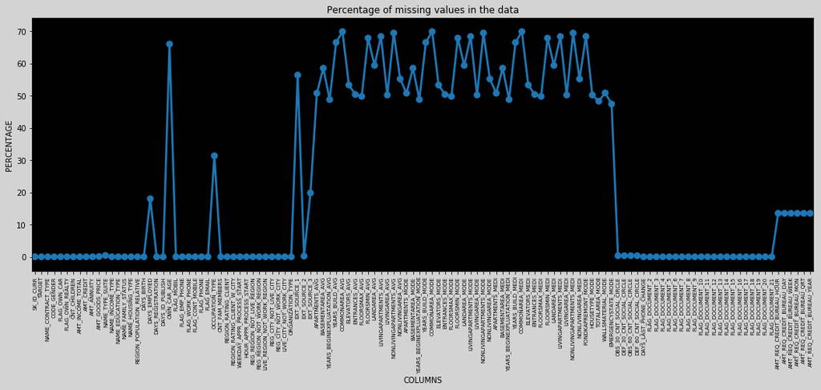

```python
plot_missing_data(app_data)
```

As we can see, there are columns where more than 60% of data are missing.  
There are two ways to handle missing data:

1. **Imputation** i.e. filling up those missing values
2. **Dropping columns** having most of the values missing

Dropping columns can be risky and may impair building our model. So, as of now, we shall keep all columns.

## 2.3 Encoding categorical variables

Categorical variables contain a finite number of categories or distinct groups. 'object' columns contain strings and are, therefore, categorical variables.

At first, let's see the distribution of data types for training and test data.

### Distribution of data types in the data

```python
app_data.dtypes.value_counts()
```

```
float64    66
int64      40
object     16
dtype: int64
```

Let's now look at the **number of unique values** in each of the categorical (or, 'object' data type) columns.

```python
app_data.select_dtypes('object').apply(pd.Series.nunique, axis = 0)
```

```
NAME_CONTRACT_TYPE             2
CODE_GENDER                    2
FLAG_OWN_CAR                   2
FLAG_OWN_REALTY                2
NAME_TYPE_SUITE                7
NAME_INCOME_TYPE               8
NAME_EDUCATION_TYPE            5
NAME_FAMILY_STATUS             6
NAME_HOUSING_TYPE              6
OCCUPATION_TYPE               18
WEEKDAY_APPR_PROCESS_START     7
ORGANIZATION_TYPE             58
FONDKAPREMONT_MODE             4
HOUSETYPE_MODE                 3
WALLSMATERIAL_MODE             7
EMERGENCYSTATE_MODE            2
dtype: int64
```

**Observation**: Few categorical variables, for example, 'NAME_CONTRACT_TYPE', have two types of data. Rest of categorical variables have more than two types of data.

### 2.3.1 Strategy for encoding

I shall use **Label Encoding** and **One-Hot Encoding** for categorical variables.  
Advantage of label encoding is that no new column is created. However, this encoding gives the categories arbitrary ordering. The value assigned to each of the categories is random.  
On other hand, one-hot encoding creates a new column for each unique category in a categorical variable. So, this encoding increases the dimentionality of the data.  
Therefore, my strategy will be as follows:

- Apply **Label Encoding**, if number of categories in a categorical variable is equal to 2
- Apply **One-Hot Encoding**, if number of categories in a categorical variable is greater than 2

Please note: For a categorical variable, number of unique values (or, categories) is always greater than or equal to 2.

### 2.3.2 Label encoding

```python
# Create a label encoder object
le = LabelEncoder()
encoded_col_count = 0

# Iterate through the columns
for col in app_data:
    if app_data[col].dtype == 'object':
        # If 2 unique categories
        if len(list(app_data[col].unique())) == 2:
            # Fit and transform column data
            app_data[col] = le.fit_transform(app_data[col])
            # Keep track of how many columns were label encoded
            encoded_col_count += 1

print('Total number of columns that were label encoded: ', str(encoded_col_count))
```

```
Total number of columns that were label encoded:  4
```

### 2.3.3 One-hot encoding

```python
app_data = pd.get_dummies(app_data)
```

```python
print('App data shape: ', app_data.shape)
```

```
App data shape:  (307507, 241)
```

**Observation**: One-hot encoding has created more columns in the data. We shall later apply technique to reduce dimensionality.

This concludes data processing. We are good to start EDA and understand given data a bit more.

# Part 3 - Exploratory data analysis (EDA)

## 3.1. Distribution of TARGET variable

Here, we shall check values in 'TARGET' column once again. Let's see how many of them are '0' and how many of them are '1'.

```python
app_data['TARGET'].value_counts()
```

```
0    282682
1     24825
Name: TARGET, dtype: int64
```

```python
def plot_distribution_of_output_labels(data, plot_title, output_col=None):
    '''
    This function plots distribution of output labels in a pie-chart.
    INPUT:
    data: data set
    plot_title: title of the plot
    output_col: the column containing output labels
    OUtPUT: pie-chart on output-labels
    '''
    plt.figure(figsize=(14,7))
    plt.subplot(121)
    if(output_col is None):
        data.value_counts().plot.pie(
            autopct = "%1.2f%%", colors = sns.color_palette("muted"), startangle = 60,
            labels = ["repayer","defaulter"],
            wedgeprops = {"linewidth":2,"edgecolor":"k"}, explode = [.1,0], shadow = True)
    else:
        data[output_col].value_counts().plot.pie(
            autopct = "%1.2f%%", colors = sns.color_palette("muted"), startangle = 60,
            labels = ["repayer","defaulter"],
            wedgeprops = {"linewidth":2,"edgecolor":"k"}, explode = [.1,0], shadow = True)
    plt.title(plot_title)
```

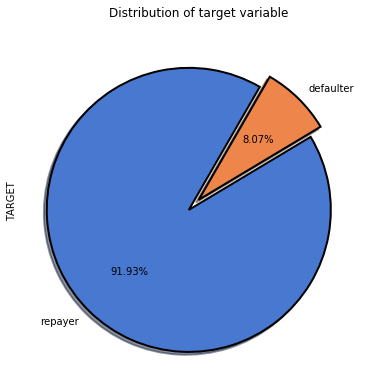

```python
plot_distribution_of_output_labels(app_data, 'Distribution of target variable', 'TARGET')
```

As we can see above, in data set,

- percentage of people repaid loan in time: 91.93%
- percentage of people didn't repay in time: 8.07%

This shows that the dataset has disproportionate ratio of observations. So, we have **Class Imbalance problem** here.

## 3.2. Feature correlation with output label

Before we proceed further, we need to change one part of the data. DAYS_BIRTH is client's age in days relative to the application, and is a negative number. Here onwards, we shall only consider the number for this age and not negative sign.

```python
# we shall disregard negative sign going forward
app_data['DAYS_BIRTH'] = abs(app_data['DAYS_BIRTH'])
```

Let's start with Pearson correlation coefficient between every variable and the target. This will give some idea on "relevance" of a feature.

```python
# Find correlations with the target and sort
corrs_with_target = app_data.corr()['TARGET'].sort_values()
```

```python
print('Top 10 most positive correlations:\n', corrs_with_target.tail(10))
```

```
Top 10 most positive correlations:
 NAME_EDUCATION_TYPE_Secondary / secondary special    0.049822
REG_CITY_NOT_WORK_CITY                               0.050992
DAYS_ID_PUBLISH                                      0.051457
CODE_GENDER                                          0.054710
DAYS_LAST_PHONE_CHANGE                               0.055219
NAME_INCOME_TYPE_Working                             0.057483
REGION_RATING_CLIENT                                 0.058901
REGION_RATING_CLIENT_W_CITY                          0.060895
DAYS_EMPLOYED                                        0.074957
TARGET                                               1.000000
Name: TARGET, dtype: float64
```

```python
print('Top 10 most negative correlations:\n', corrs_with_target.head(10))
```

```
Top 10 most negative correlations:
 EXT_SOURCE_3                           -0.178926
EXT_SOURCE_2                           -0.160471
EXT_SOURCE_1                           -0.155317
DAYS_BIRTH                             -0.078242
NAME_EDUCATION_TYPE_Higher education   -0.056593
NAME_INCOME_TYPE_Pensioner             -0.046211
ORGANIZATION_TYPE_XNA                  -0.045989
FLOORSMAX_AVG                          -0.044009
FLOORSMAX_MEDI                         -0.043773
FLOORSMAX_MODE                         -0.043231
Name: TARGET, dtype: float64
```

Of course, we shall disregard correlation of 'TARGET' with itself.

- Top 4 positive correlations with 'TARGET': DAYS_EMPLOYED, REGION_RATING_CLIENT_W_CITY, REGION_RATING_CLIENT, NAME_INCOME_TYPE_Working
- Top 4 negative correlations with 'TARGET': EXT_SOURCE_3, EXT_SOURCE_2, EXT_SOURCE_1, DAYS_BIRTH

Let's define a reusable function at first, to draw kernel density estimation plot of these variables with TARGET.

```python
del corrs_with_target
gc.collect()
```

```
1645
```

```python
def kde_plot_with_target(col_name):
    '''
    This function generates kernel density estimation plot (KDE) of input column with the TARGET.
    This function works on 'app_data' dataframe
    INPUT:
    col_name: Name of the input column
    OUTPUT:
    KDE plot with TARGET
    '''
    plt.figure(figsize = (10, 8))

    # KDE plot of loans that were repaid on time
    sns.kdeplot(app_data.loc[app_data['TARGET'] == 0, col_name], label = 'Repaid in time')

    # KDE plot of loans which were not repaid on time
    sns.kdeplot(app_data.loc[app_data['TARGET'] == 1, col_name], label = 'Difficulty in payment')

    # Labeling of plot
    plt.xlabel(col_name)
    plt.ylabel('Density')
    plt.title('Distribution of {} by TARGET'.format(col_name))
```

### 3.2.1 Days of employment

DAYS_EMPLOYED has highest postive correlation with TARGET. Let's see the histogram for this data. This data shows how many days before the application the person started current employment. The time is only relative to the application and thus is negative.

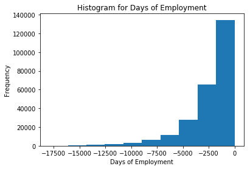

```python
app_data['DAYS_EMPLOYED'].plot.hist(title = 'Histogram for Days of Employment')
plt.xlabel('Days of Employment')
```

This distribution shows that people who are newly employed are more likely to apply for the loan. Let's see KDE plot with TARGET.

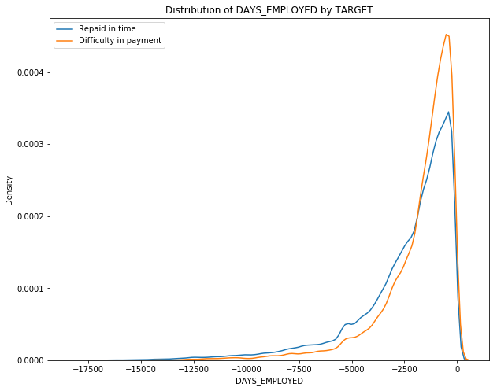

```python
kde_plot_with_target('DAYS_EMPLOYED')
```

This plot isn't that conclusive, and skewed because maximum borrowers have very less days in employment. So, both chance of repayment and risk of defaulting are high when days in employment are low.

### 3.2.2 Ratings of client's region

REGION_RATING_CLIENT_W_CITY and REGION_RATING_CLIENT contain second and third highest positive correlations with TARGET. Let's check their histograms.

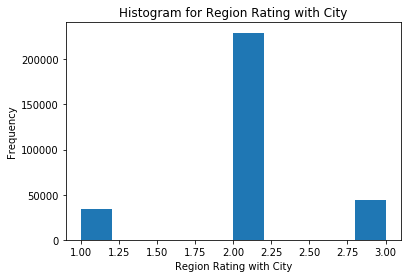

```python
app_data['REGION_RATING_CLIENT_W_CITY'].plot.hist(title = 'Histogram for Region Rating with City')
plt.xlabel('Region Rating with City')
```

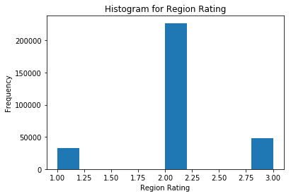

```python
app_data['REGION_RATING_CLIENT'].plot.hist(title = 'Histogram for Region Rating')
plt.xlabel('Region Rating')
```

As we can see above:

- Both 'REGION_RATING_CLIENT' and 'REGION_RATING_CLIENT_W_CITY' contain almost identical data
- The regions having rating between 2 and 2.25 contain most number of clients for the loans.

Let's now see KDE plot for these variables.

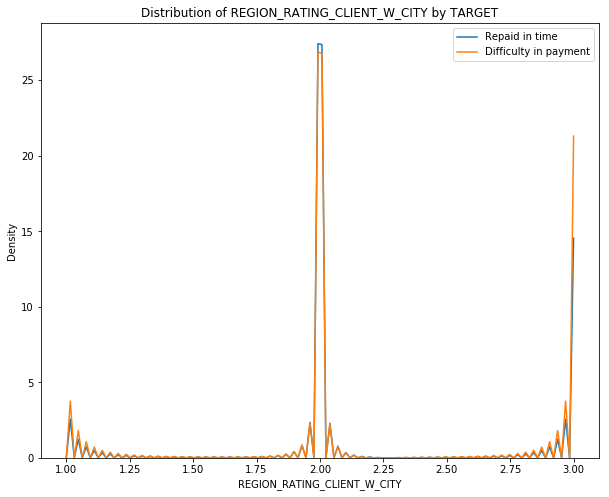

```python
kde_plot_with_target('REGION_RATING_CLIENT_W_CITY')
```

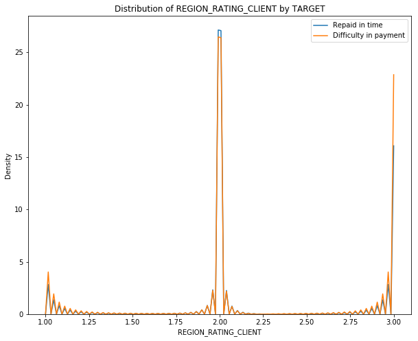

```python
kde_plot_with_target('REGION_RATING_CLIENT')
```

As expected from the histograms, densities for both repayment and defaulting are high for the regions having rating around 2.00. We can see a spike for regions having rating close to 3.00.

### 3.2.3 Score from external data source

EXT_SOURCE_1, EXT_SOURCE_2 and EXT_SOURCE_3 have highest negative correlations with TARGET.  
Let us see kernel density estimation plot (KDE) of these variables with the TARGET.

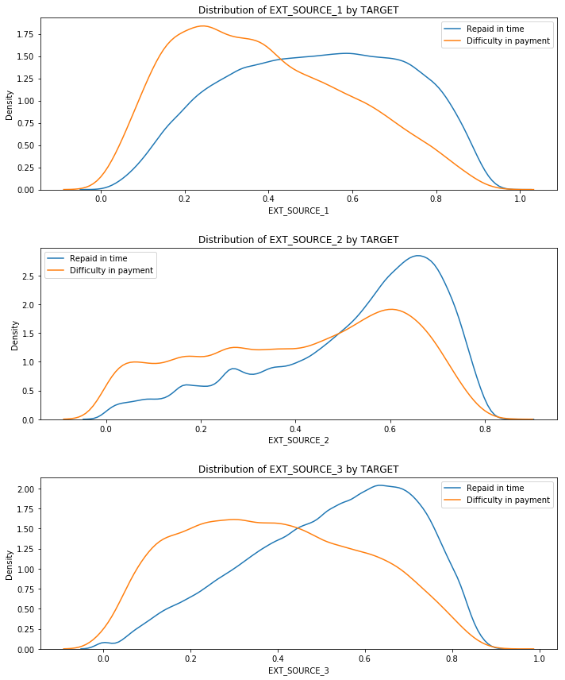

```python
plt.figure(figsize = (10, 12))

# iterate through the sources
for i, source in enumerate(['EXT_SOURCE_1', 'EXT_SOURCE_2', 'EXT_SOURCE_3']):

    # create a new subplot for each source
    plt.subplot(3, 1, i + 1)
    # plot repaid loans
    sns.kdeplot(app_data.loc[app_data['TARGET'] == 0, source], label = 'Repaid in time')
    # plot loans that were not repaid
    sns.kdeplot(app_data.loc[app_data['TARGET'] == 1, source], label = 'Difficulty in payment')

    # Label the plots
    plt.title('Distribution of {} by TARGET'.format(source))
    plt.xlabel(source)
    plt.ylabel('Density')

plt.tight_layout(h_pad = 2.5)
```

### 3.2.1 Client's age

DAYS_BIRTH has fourth highest negative correlation with TARGET. That means, as the client gets older, they are less likely to default on their loan.

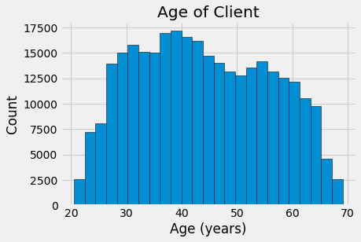

```python
# Set the style of plots
plt.style.use('fivethirtyeight')

# Plot the distribution of ages in years
plt.hist(app_data['DAYS_BIRTH'] / 365, edgecolor = 'k', bins = 25)
plt.title('Age of Client'); plt.xlabel('Age (years)'); plt.ylabel('Count')
```

As we can see from this distribution, mostly people have taken loans when their ages are around 40 years.  
To visualize the effect of the age on the target, we will next make a kernel density estimation plot (KDE).

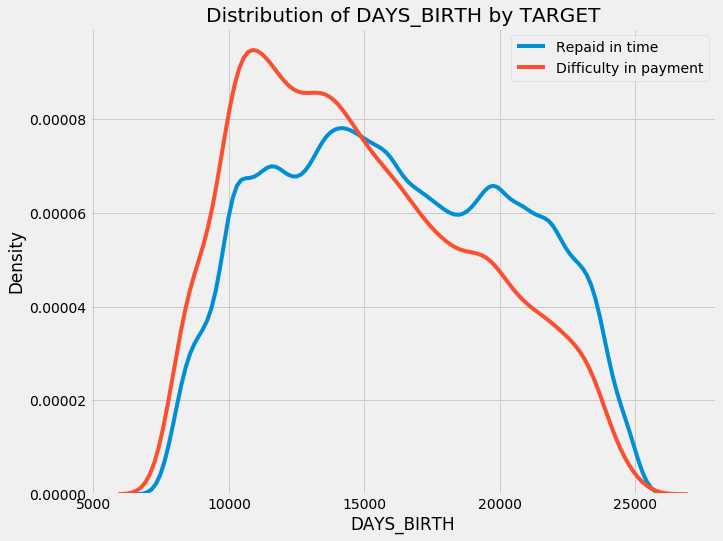

```python
kde_plot_with_target('DAYS_BIRTH')
```

As it is shown in the curve above, younger applicants are more likely to not repay the loan.

# Part 4 - Feature transformation

## 4.1 Impute missing values

We have seen analysis of missing values in section 2.2.2. Before we attempt for feature scaling, we shall impute missing values. As mentioned before, we won't drop any column.

```python
imputer = Imputer(strategy='median')
```

```python
app_data_filled = pd.DataFrame(imputer.fit_transform(app_data))
app_data_filled.columns = app_data.columns
app_data_filled.index = app_data.index
app_data_filled.head()
```

|  | SK_ID_CURR | TARGET | NAME_CONTRACT_TYPE | CODE_GENDER | FLAG_OWN_CAR | FLAG_OWN_REALTY | CNT_CHILDREN | AMT_INCOME_TOTAL | AMT_CREDIT | AMT_ANNUITY | ... | HOUSETYPE_MODE_terraced house | WALLSMATERIAL_MODE_Block | WALLSMATERIAL_MODE_Mixed | WALLSMATERIAL_MODE_Monolithic | WALLSMATERIAL_MODE_Others | WALLSMATERIAL_MODE_Panel | WALLSMATERIAL_MODE_Stone, brick | WALLSMATERIAL_MODE_Wooden | EMERGENCYSTATE_MODE_No | EMERGENCYSTATE_MODE_Yes |
| --- | --- | --- | --- | --- | --- | --- | --- | --- | --- | --- | --- | --- | --- | --- | --- | --- | --- | --- | --- | --- | --- |
| 0 | 100002.0 | 1.0 | 0.0 | 1.0 | 0.0 | 1.0 | 0.0 | 202500.0 | 406597.5 | 24700.5 | ... | 0.0 | 0.0 | 0.0 | 0.0 | 0.0 | 0.0 | 1.0 | 0.0 | 1.0 | 0.0 |
| 1 | 100003.0 | 0.0 | 0.0 | 0.0 | 0.0 | 0.0 | 0.0 | 270000.0 | 1293502.5 | 35698.5 | ... | 0.0 | 1.0 | 0.0 | 0.0 | 0.0 | 0.0 | 0.0 | 0.0 | 1.0 | 0.0 |
| 2 | 100004.0 | 0.0 | 1.0 | 1.0 | 1.0 | 1.0 | 0.0 | 67500.0 | 135000.0 | 6750.0 | ... | 0.0 | 0.0 | 0.0 | 0.0 | 0.0 | 0.0 | 0.0 | 0.0 | 0.0 | 0.0 |
| 3 | 100006.0 | 0.0 | 0.0 | 0.0 | 0.0 | 1.0 | 0.0 | 135000.0 | 312682.5 | 29686.5 | ... | 0.0 | 0.0 | 0.0 | 0.0 | 0.0 | 0.0 | 0.0 | 0.0 | 0.0 | 0.0 |
| 4 | 100007.0 | 0.0 | 0.0 | 1.0 | 0.0 | 1.0 | 0.0 | 121500.0 | 513000.0 | 21865.5 | ... | 0.0 | 0.0 | 0.0 | 0.0 | 0.0 | 0.0 | 0.0 | 0.0 | 0.0 | 0.0 |

5 rows × 241 columns

```python
app_data_filled.shape
```

```
(307507, 241)
```

```python
print('Is there any NaN: ', np.any(np.isnan(app_data_filled)))
```

```
Is there any NaN:  False
```

## 4.2 Feature scaling

We shall use MinMaxScaler to scale all features in the data.

```python
scaler = MinMaxScaler(feature_range = (0, 1))
```

```python
app_data_filled_scaled = scaler.fit_transform(app_data_filled)
app_data_filled_scaled = pd.DataFrame(app_data_filled_scaled, columns=app_data_filled.columns)
app_data_filled_scaled.head()
```

|  | SK_ID_CURR | TARGET | NAME_CONTRACT_TYPE | CODE_GENDER | FLAG_OWN_CAR | FLAG_OWN_REALTY | CNT_CHILDREN | AMT_INCOME_TOTAL | AMT_CREDIT | AMT_ANNUITY | ... | HOUSETYPE_MODE_terraced house | WALLSMATERIAL_MODE_Block | WALLSMATERIAL_MODE_Mixed | WALLSMATERIAL_MODE_Monolithic | WALLSMATERIAL_MODE_Others | WALLSMATERIAL_MODE_Panel | WALLSMATERIAL_MODE_Stone, brick | WALLSMATERIAL_MODE_Wooden | EMERGENCYSTATE_MODE_No | EMERGENCYSTATE_MODE_Yes |
| --- | --- | --- | --- | --- | --- | --- | --- | --- | --- | --- | --- | --- | --- | --- | --- | --- | --- | --- | --- | --- | --- |
| 0 | 0.000000 | 1.0 | 0.0 | 1.0 | 0.0 | 1.0 | 0.0 | 0.009839 | 0.090287 | 0.090032 | ... | 0.0 | 0.0 | 0.0 | 0.0 | 0.0 | 0.0 | 1.0 | 0.0 | 1.0 | 0.0 |
| 1 | 0.000003 | 0.0 | 0.0 | 0.0 | 0.0 | 0.0 | 0.0 | 0.013594 | 0.311736 | 0.132924 | ... | 0.0 | 1.0 | 0.0 | 0.0 | 0.0 | 0.0 | 0.0 | 0.0 | 1.0 | 0.0 |
| 2 | 0.000006 | 0.0 | 1.0 | 1.0 | 1.0 | 1.0 | 0.0 | 0.002328 | 0.022472 | 0.020025 | ... | 0.0 | 0.0 | 0.0 | 0.0 | 0.0 | 0.0 | 0.0 | 0.0 | 0.0 | 0.0 |
| 3 | 0.000011 | 0.0 | 0.0 | 0.0 | 0.0 | 1.0 | 0.0 | 0.006084 | 0.066837 | 0.109477 | ... | 0.0 | 0.0 | 0.0 | 0.0 | 0.0 | 0.0 | 0.0 | 0.0 | 0.0 | 0.0 |
| 4 | 0.000014 | 0.0 | 0.0 | 1.0 | 0.0 | 1.0 | 0.0 | 0.005333 | 0.116854 | 0.078975 | ... | 0.0 | 0.0 | 0.0 | 0.0 | 0.0 | 0.0 | 0.0 | 0.0 | 0.0 | 0.0 |

5 rows × 241 columns

## 4.3 Perform Dimensionality Reduction

As we have seen, dimension of data is 240, excluding output label. We have already scaled our data as well. Now, we shall attempt to reduce dimensionality of this data-set.  
Working with data in high-dimensional space often results in the problem, known as [curse of dimensionality](https://en.wikipedia.org/wiki/Curse_of_dimensionality). Therefore, dimensionality reduction will help us to avoid that problem.

**Overall strategy**:

- Step 1 - Exclude 'TARGET' from app data
- Step 2 - Reduce dimensionality of data (excluding 'TARGET')
- Step 3 - Inspect few features
- Step 4 - Reconstruct the data set

### Step 1 - Exclude 'TARGET' from app data

We shall keep training labels separate.

```python
# keep training labels separate
training_labels = app_data_filled_scaled['TARGET']

# drop training labels from training set
app_data_filled_scaled_no_output = app_data_filled_scaled
app_data_filled_scaled_no_output = app_data_filled_scaled_no_output.drop(['TARGET'], axis=1)
app_data_filled_scaled_no_output.shape
```

```
(307507, 240)
```

### Step 2 - Reduce dimensionality of data

Use sklearn's [PCA](https://scikit-learn.org/stable/modules/generated/sklearn.decomposition.PCA.html) class to apply principal component analysis on the data. This will help in finding the vectors of maximal variance in the data.

**Strategy**:

- Let's first fit PCA to entire data set
- Then, create a scree plot explaining variance per principal component
- From this plot, decide on number of principal components to be retained
- Then, re-apply PCA with that many n_components and reduce dimensionality of the data set accordingly

```python
# Apply PCA to the data.
pca = PCA()
pca.fit(app_data_filled_scaled_no_output)
```

```
PCA(copy=True, iterated_power='auto', n_components=None, random_state=None,
  svd_solver='auto', tol=0.0, whiten=False)
```

Now, let's create a scree-plot function.

```python
def scree_plot(pca):
    '''
    Creates a scree plot associated with the principal components

    INPUT: pca - PCA in scikit learn

    OUTPUT:
            None
    '''
    num_components=len(pca.explained_variance_ratio_)
    ind = np.arange(num_components)
    vals = pca.explained_variance_ratio_

    plt.figure(figsize=(10, 6))
    ax = plt.subplot(111)
    cumvals = np.cumsum(vals)
    ax.bar(ind, vals)
    ax.plot(ind, cumvals)
    for i in range(num_components):
        ax.annotate(r"%s%%" % ((str(vals[i]*100)[:4])), (ind[i]+0.2, vals[i]), va="bottom", ha="center", fontsize=12)

    ax.xaxis.set_tick_params(width=0)
    ax.yaxis.set_tick_params(width=2, length=12)

    ax.set_xlabel("Principal Component")
    ax.set_ylabel("Variance Explained (%)")
    plt.title('Explained Variance Per Principal Component')

print("Function 'scree_plot' has been defined.")
```

```
Function 'scree_plot' has been defined.
```

Create the plot.

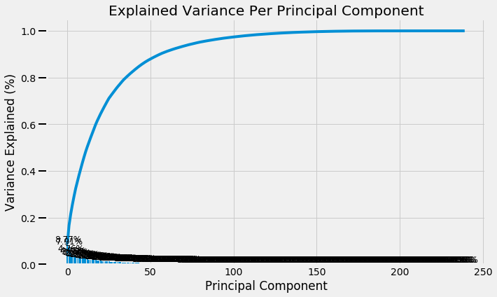

```python
scree_plot(pca)
```

From this scree plot, we can see that about 40 principal components can cover more than 80% of the variance of the data. So, we shall retain 40 components.

```python
pca_40 = PCA(n_components=40)
app_pca = pca_40.fit_transform(app_data_filled_scaled_no_output)
pca_40.explained_variance_ratio_.sum()
```

```
0.8238528197436833
```

```python
print('Reduced dimensionality of the data: ', app_pca.shape)
```

```
Reduced dimensionality of the data:  (307507, 40)
```

### Step 3 - Inspect few principal components

Let's inspect our principal components for a moment.

```python
def pca_weights(pca, i, df_train):
    '''
    Map weights for the ith principal component to corresponding feature names,
    and return the sorted list of weights.
    INPUT:
    pca: the PCA component
    i: location of the component
    df_train: training dataset
    OUTPUT:
    weights: weights associated
    '''
    df = pd.DataFrame(pca.components_, columns=list(df_train.columns))
    weights = df.iloc[i].sort_values(ascending=False)
    return weights
```

```python
def plot_PCA_feature_associations(pca, i, df_train):
    '''
    Map weights for the ith principal component to corresponding feature names,
    and then plot linked values, sorted by weight.
    INPUT:
    pca: the PCA component
    i: location of the component
    df_train: training dataset
    OUTPUT: none
    '''
    row = pca_weights(pca, i, df_train)
    row.plot(kind='bar', figsize=(18, 8))
    plt.show()
```

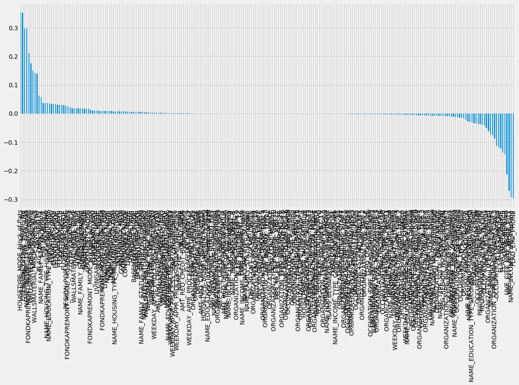

```python
plot_PCA_feature_associations(pca_40, 0, app_data_filled_scaled_no_output)
```

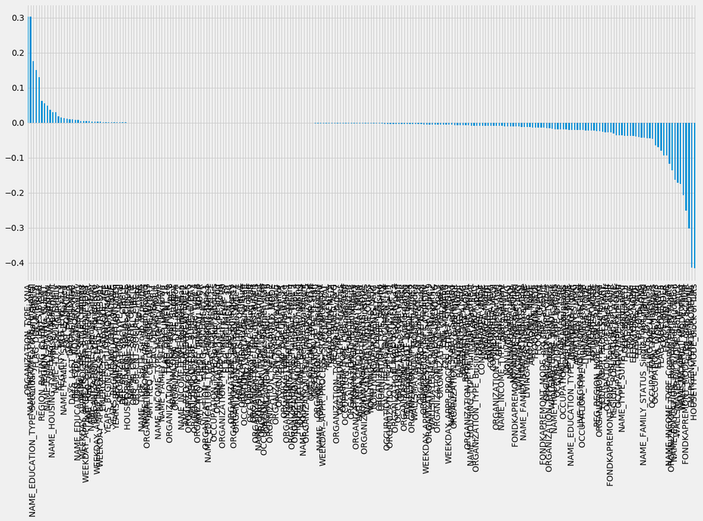

```python
plot_PCA_feature_associations(pca_40, 1, app_data_filled_scaled_no_output)
```

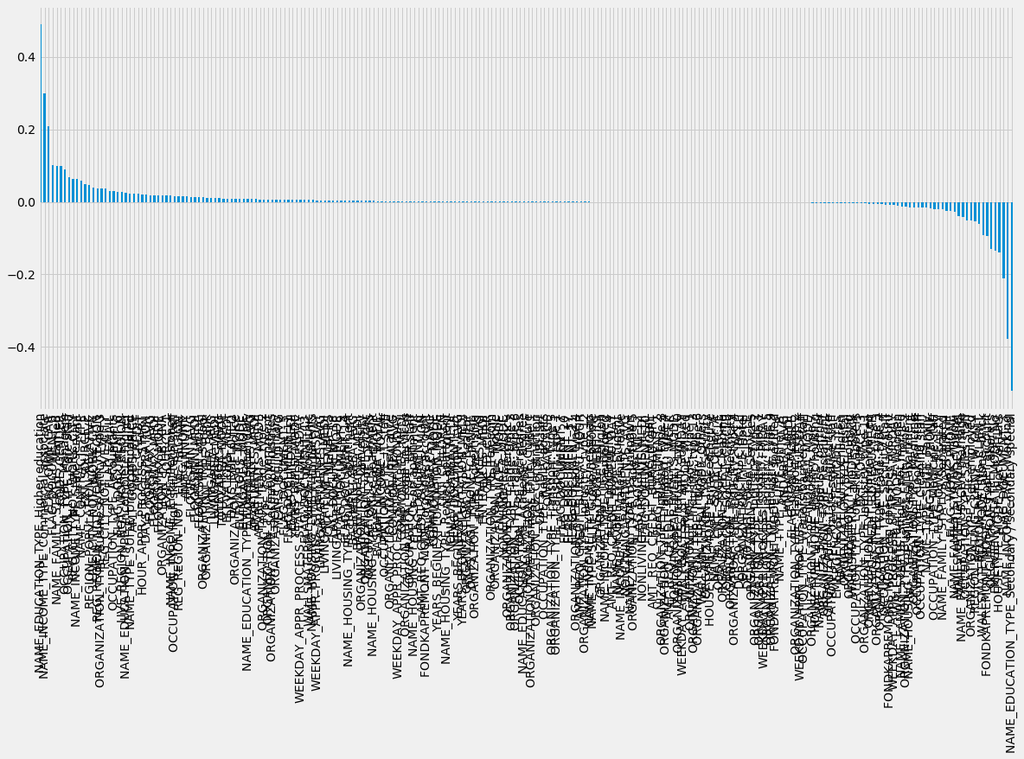

```python
plot_PCA_feature_associations(pca_40, 2, app_data_filled_scaled_no_output)
```

Observations are as follows:

- For first principal component: High positive value for 'HOUSETYPE_MODE block of flats' and high negative value for 'FLAG_EMP_PHONE'. Interpretation: People staying in flats usually don't provide work phone.
- For second principal component: High positive value for 'ORGANIZATION_TYPE_XNA' and high negative value for 'HOUSETYPE_MODE block of flats'. Interpretation: The organization where client works is correlated to where the client stays.
- For third principal component: High positive value for 'NAME_EDUCATION_TYPE Higher education' and high negative value for 'NAME_EDUCATION_TYPE Secondary / secondary special'. Interpretation: People usually will specify their highest level of education. For example, they won't specify their education level as secondary eductation if they have higher degrees.

### Step 4 - Reconstruct the data set

This is our final step of dimensionality reduction. We need to reconstruct our dataset with reduced dimensionality.  
We shall create a dataframe from PCA output, and add back training 'TARGET' labels to it.

```python
def form_dataframe(data, pc_count, pc_name_prefix):
    '''
    Form dataframe from n-dimensional data.
    Column names will be formed from given prefix and internal counter value
    INPUT:
    data: n-dimensional array of data (output of PCA)
    pc_count: count of principal components
    pc_name_prefix: prefix for the column names
    OUTPUT:
    df: created dataframe
    '''
    df_cols = []
    for i in range(pc_count):
        column_name = pc_name_prefix + '_' + str(i)
        df_cols.append(column_name)
    df = pd.DataFrame(data, columns = df_cols)

    return df
```

```python
pca_40.components_.shape[0]
```

```
40
```

```python
app_pca_df = form_dataframe(app_pca, pca_40.components_.shape[0], 'pc')
app_pca_df['TARGET'] = training_labels
app_pca_df.shape
```

```
(307507, 41)
```

```python
app_pca_df.head()
```

|  | pc_0 | pc_1 | pc_2 | pc_3 | pc_4 | pc_5 | pc_6 | pc_7 | pc_8 | pc_9 | ... | pc_31 | pc_32 | pc_33 | pc_34 | pc_35 | pc_36 | pc_37 | pc_38 | pc_39 | TARGET |
| --- | --- | --- | --- | --- | --- | --- | --- | --- | --- | --- | --- | --- | --- | --- | --- | --- | --- | --- | --- | --- | --- |
| 0 | 0.128204 | -1.089639 | -1.076252 | -0.074952 | 0.755659 | -0.386436 | -0.135746 | -0.017955 | -0.246724 | -0.636081 | ... | 0.046282 | -0.050894 | -0.038376 | 0.053395 | 0.080508 | -0.001997 | 0.262927 | -0.005350 | -0.092090 | 1.0 |
| 1 | 0.682340 | -0.852665 | 0.730223 | -0.418630 | -1.171512 | 0.366628 | 0.313577 | 0.888049 | 0.544197 | -0.681026 | ... | 0.103987 | 0.244710 | 0.024796 | 0.032576 | 0.128886 | -0.089402 | 0.048176 | 0.047527 | -0.125362 | 0.0 |
| 2 | -0.812980 | 0.243539 | -0.185014 | 0.353403 | 0.758875 | -1.008241 | 0.314043 | -0.536288 | 0.769288 | -0.482451 | ... | 0.090089 | 0.042011 | -0.036468 | -0.050001 | 0.038371 | -0.104321 | -0.276757 | 0.019675 | 0.104249 | 0.0 |
| 3 | -0.696205 | 0.371832 | -0.736416 | -0.614503 | 0.229579 | -0.121915 | -0.477288 | -0.583651 | 0.175671 | 0.119669 | ... | -0.040446 | -0.221902 | -0.169901 | 0.245817 | -0.060216 | -0.085750 | -0.084958 | -0.062033 | -0.089886 | 0.0 |
| 4 | -1.005727 | 0.472434 | -0.041510 | -0.072092 | 1.128140 | -0.791977 | -0.357309 | 0.340609 | 0.112422 | 0.524475 | ... | -0.581939 | -0.117028 | 0.052835 | -0.200926 | 0.284628 | -0.036249 | -0.370870 | -0.334618 | 0.099830 | 0.0 |

5 rows × 41 columns

```python
del app_data
del app_data_filled
del app_data_filled_scaled
del app_data_filled_scaled_no_output
gc.collect()
```

```
57980
```

# Part 5 - Select classification model and metrics

In this part, data to be used is contained in 'app_pca_df' dataframe. We shall create training and test data from this set and evaluate multiple models.

## 5.1 - Prepare training and test data

As we have seen in section 3.1, 8.07% data contains 'TARGET' as 1. 91.93% data contains 'TARGET' as 0. So, we want train and test data to have, at least, nearly similar distribution. In this situation, we can check on following two strategies.

### Strategy 1

- Segregate data into two groups i.e. data_set_0 and data_set_1, based on 'TARGET' value as 0 and 1 respectively
- For each data set, separate output labels (i.e. 'TARGET' column) from input parameters
- Split each of these subsets into training set and test set using 80:20 ratio.
  - This will create following 4 sets from data_set_0: X_train_0, X_test_0, Y_train_0, Y_test_0
  - Simialrly, 4 sets from data_set_1 will be created: X_train_1, X_test_1, Y_train_1, Y_test_1
- Create training data by merging:
  - input parameters for training: merge X_train_0 and X_train_1
  - output labels for training: merge Y_train_0 and Y_train_1
- Create test data by merging:
  - input parameters for testing: merge X_test_0 and X_test_1
  - output labels for testing: merge Y_test_0 and Y_test_1

### Strategy 2

- Split data into output labels and input features
- Split labels and features into training and test sets keeping 80:20 ratio

Define function for **strategy 1**

```python
def split_test_train_strategy1(df, output_col):
    '''
    This function splits data into training and test sets,
    based on the strategy 1 described above.
    INPUT:
    df: dataframe containing data
    output_col: output column containing labels
    OUTPUT:
    X_train: Input parameters for training
    X_test: Input parameters for testing
    Y_train: Output labels for training
    Y_test: Output labels for testing
    '''
    # create X, Y with having label 0
    data_set_0 = df[df[output_col] == 0]
    Y_0 = data_set_0[output_col]
    X_0 = data_set_0.drop([output_col], axis=1)
    # create X, Y having label 1
    data_set_1 = df[df[output_col] == 1]
    Y_1 = data_set_1[output_col]
    X_1 = data_set_1.drop([output_col], axis=1)
    # split into train, test
    X_train_0, X_test_0, Y_train_0, Y_test_0 = train_test_split(X_0, Y_0, test_size=0.2, random_state = 40)
    X_train_1, X_test_1, Y_train_1, Y_test_1 = train_test_split(X_1, Y_1, test_size=0.2, random_state = 40)
    X_train = pd.concat([X_train_0, X_train_1], ignore_index=True)
    Y_train = pd.concat([Y_train_0, Y_train_1], ignore_index=True)
    X_test = pd.concat([X_test_0, X_test_1], ignore_index=True)
    Y_test = pd.concat([Y_test_0, Y_test_1], ignore_index=True)

    return X_train, X_test, Y_train, Y_test
```

Define function for **strategy 2**

```python
def split_test_train_strategy2(df, output_col):
    '''
    This function splits data into training and test sets,
    based on the strategy 2 described above.
    INPUT:
    df: dataframe containing data
    output_col: output column containing labels
    OUTPUT:
    X_train: Input parameters for training
    X_test: Input parameters for testing
    Y_train: Output labels for training
    Y_test: Output labels for testing
    '''
    # create X, Y
    Y = df[output_col]
    X = df.drop([output_col], axis=1)
    # split into train, test
    X_train, X_test, Y_train, Y_test = train_test_split(X, Y, test_size=0.2, random_state = 40)

    return X_train, X_test, Y_train, Y_test
```

### Evaluate strategy 1

Evaluation will be done by seeing distribution of labels in both training and test data

```python
X_train, X_test, Y_train, Y_test = split_test_train_strategy1(app_pca_df, 'TARGET')
```

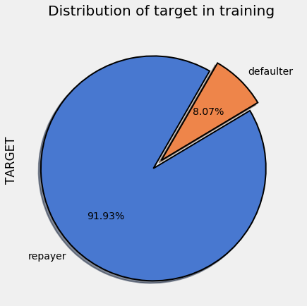

```python
plot_distribution_of_output_labels(Y_train, 'Distribution of target in training')
```

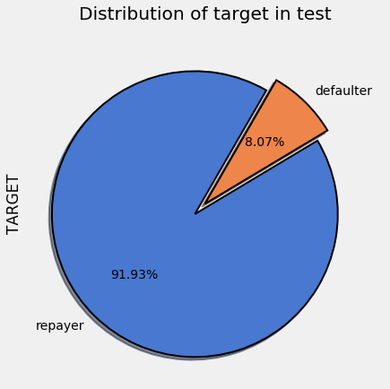

```python
plot_distribution_of_output_labels(Y_test, 'Distribution of target in test')
```

### Evaluate strategy 2

Evaluation will be done by seeing distribution of labels in both training and test data

```python
X_train, X_test, Y_train, Y_test = split_test_train_strategy2(app_pca_df, 'TARGET')
```

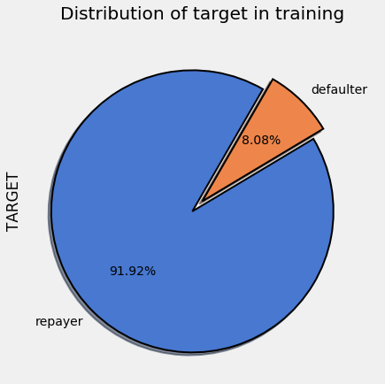

```python
plot_distribution_of_output_labels(Y_train, 'Distribution of target in training')
```

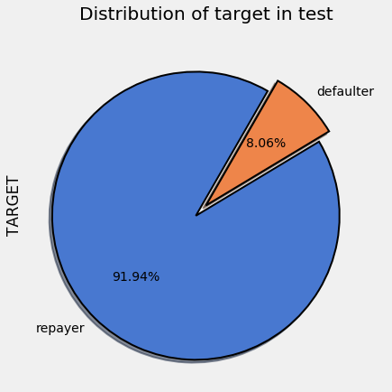

```python
plot_distribution_of_output_labels(Y_test, 'Distribution of target in test')
```

### Conclusion

We are not seeing much difference between **strategy 1** and **strategy 2**. Moreover, strategy 1 will alter natural ordering of data, since we split and merge data based on labels. Therefore, we shall go ahead with our strategy 2, which is simpler and preserve natural ordering of data.

So, now we are ready with X_train, Y_train, X_test, Y_test to test different classification models.

## 5.2 - Define metrics to evaluate classification model

Let's start with confusion matrix for binary classification.

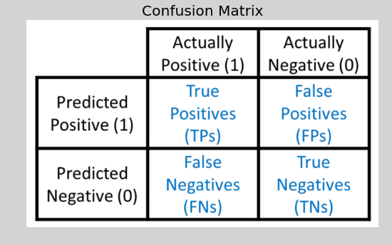

```python
image = np.array(Image.open(r"images/confusion_matrix.png"))
fig = plt.figure(figsize=(8,5))
plt.imshow(image,interpolation="bilinear")
plt.axis("off")
fig.set_facecolor("lightgrey")
plt.title("Confusion Matrix")
plt.show()
```

In our context,

- output = 1 means client will have payment difficulties
- output = 0 means client will repay in time

Following metrics will be determined for each of our classification models:

- **Accuracy**
  - Accuracy, as name suggests, measures the accuracy of the model in predictions
  - Error = (1 - Accuracy)
  - This metric assumes equal costs for both kinds of errors i.e. false postives and false negatives
  - Accuracy may not be good metric if cost of misclassification/error is high
  - Formula: (TP + TN) / (TP + FP + FN + TN)
- **Recall**
  - This metric measures **sensitivity** of the model
  - Recall shows how many of "actually positives" are predicted as "true positives" by the model
  - Recall is a good metric when the cost of 'False Negative' is high. In our context, 'False Negative' means approving loan to a client when there is chance of defaulting.
  - Formula: (True Positives) / (Actually Positives) = TP / (TP + FN)
- **Precision**
  - Precision shows how precise the model is in predicting postives.
  - Precision is a good metric when the cost of 'False Positive' is high. In our context, 'False Positive' means loosing a good client.
  - Formula: (True Positives) / (Predicted Positives) = TP / (TP + FP)
- **F1 score**
  - This is harmonic mean of precision and recall
  - F1 score ranges from 0 (means, worst) to 1 (means, perfect precision and recall)
  - This is a good metric when we want to give equal importance to both precision and recall
  - Formula: 2 *(Precision* Recall) / (Precision + Recall)
- **Receiver Operating Characteristic curve and Area Under Curve (ROC curve and AUC)**
  - ROC curve is used to assess the performance of the classifier over its entire operating range
  - For a perfect classifier the ROC curve will go straight up the Y axis and then along the X axis
  - Diagonal curve indicates worst power of the classifier
  - Area Under Curve (AUC) is the most common metric related to ROC curve
  - AUC for most classifiers usually ranges between 0.5 (that means, classifier is probably randomly guessing) to 1 (that means, perfect classifier)
  - AUC < 0.5 means something is wrong with the model or the data or both

Let's now, define a function to evaluate a classification model.

```python
def eval_model(model, dtrain_X, dtrain_Y, dtest_X, dtest_Y, cols=None):
    '''
    This function takes an classification model, fits that model to training data,
    predicts on test data and creates evaluation metrics
    INPUT:
    model: the model to be evaluated
    dtrain_X: training data
    dtrain_Y: training labels
    dtest_X: test data
    dtest_Y: test labels
    cols: columns of the data
    OUTPUT:
    evaluation metrics, ROC curve and the area under the curve
    '''
    model.fit(dtrain_X[cols],dtrain_Y)
    predictions = model.predict(dtest_X[cols])
    print(model)

    print("Accuracy score: ", accuracy_score(predictions,dtest_Y))
    print("Recall score: ", recall_score(predictions,dtest_Y))
    print("Classification report:\n",classification_report(predictions,dtest_Y))

    fig = plt.figure(figsize=(10,8))
    ax = fig.add_subplot(111)
    prediction_probabilities = model.predict_proba(dtest_X[cols])[:,1]
    fpr , tpr , thresholds = roc_curve(dtest_Y,prediction_probabilities)
    ax.plot(fpr,tpr,label = ["Area under curve : ",auc(fpr,tpr)],linewidth=2,linestyle="dotted")
    ax.plot([0,1],[0,1],linewidth=2,linestyle="dashed")
    plt.legend(loc="best")
    plt.title("ROC-CURVE and AREA UNDER CURVE")
    ax.set_facecolor("k")
```

### ROC AUC as metric for model selection

For our model selection, we shall use each model's **ROC AUC** value.

#### ROC AUC

Area under ROC curve is a performance measurement for classification problem at various thresholds settings. ROC is a probability curve and AUC represents degree or measure of separability. It tells how much model is capable of distinguishing between classes.

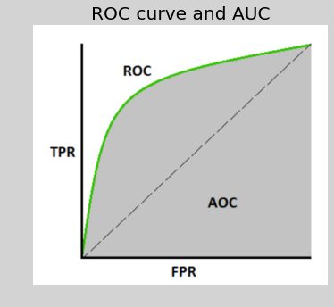

```python
image = np.array(Image.open(r"images/ROC_AUC.png"))
fig = plt.figure(figsize=(8,5))
plt.imshow(image,interpolation="bilinear")
plt.axis("off")
fig.set_facecolor("lightgrey")
plt.title("ROC curve and AUC")
plt.show()
```

Please refer to the confusion matrix above, in section 5.2 to understand certain terms used below.

TPR or true positive rate is a measure for 'recall' or sensitivity. FPR or false positive rate is a measure for expectancy of the false positives from the model.

TPR = TP / (TP + FN)

FPR = 1 - specificity = 1 - TN / (TN + FP) = FP / (TN + FP)

AUC ranges in value from 0 to 1. Higher the AUC, better the model is at predicting who will repay the loan in time and who will have difficulties in repaying the loan.

AUC as a metric is appropriate for following reasons:

- AUC provides an aggregate measure of performance across all possible classification thresholds.
- AUC is **scale-invariant**. It measures how well predictions are ranked, rather than their absolute values.
- AUC is **classification-threshold-invariant**. It measures the quality of the model's predictions irrespective of what classification threshold is chosen.

## 5.3 - Evaluate binary classification models

### 5.3.1 - LogisticRegression

```
LogisticRegression(C=1.0, class_weight=None, dual=False, fit_intercept=True,
          intercept_scaling=1, max_iter=100, multi_class='warn',
          n_jobs=None, penalty='l2', random_state=None, solver='warn',
          tol=0.0001, verbose=0, warm_start=False)
Accuracy score:  0.9194172547234236
Recall score:  0.6666666666666666
Classification report:
               precision    recall  f1-score   support

         0.0       1.00      0.92      0.96     61499
         1.0       0.00      0.67      0.00         3

   micro avg       0.92      0.92      0.92     61502
   macro avg       0.50      0.79      0.48     61502
weighted avg       1.00      0.92      0.96     61502
```

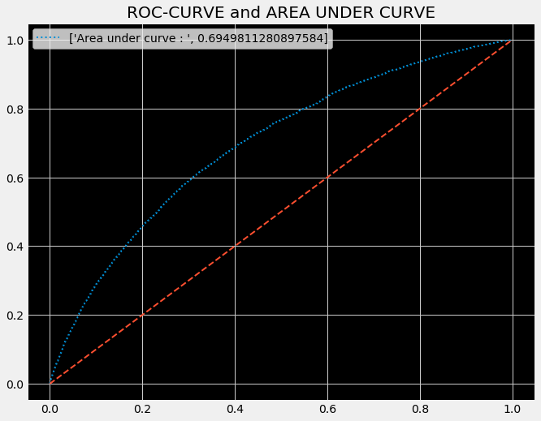

```python
logit = LogisticRegression()
eval_model(logit, X_train, Y_train, X_test, Y_test, X_train.columns)
```

### 5.3.2 - RandomForestClassifier

```
RandomForestClassifier(bootstrap=True, class_weight=None, criterion='gini',
            max_depth=None, max_features='auto', max_leaf_nodes=None,
            min_impurity_decrease=0.0, min_impurity_split=None,
            min_samples_leaf=1, min_samples_split=2,
            min_weight_fraction_leaf=0.0, n_estimators=10, n_jobs=None,
            oob_score=False, random_state=None, verbose=0,
            warm_start=False)
Accuracy score:  0.9183766381581087
Recall score:  0.23529411764705882
Classification report:
               precision    recall  f1-score   support

         0.0       1.00      0.92      0.96     61383
         1.0       0.01      0.24      0.01       119

   micro avg       0.92      0.92      0.92     61502
   macro avg       0.50      0.58      0.48     61502
weighted avg       1.00      0.92      0.96     61502
```

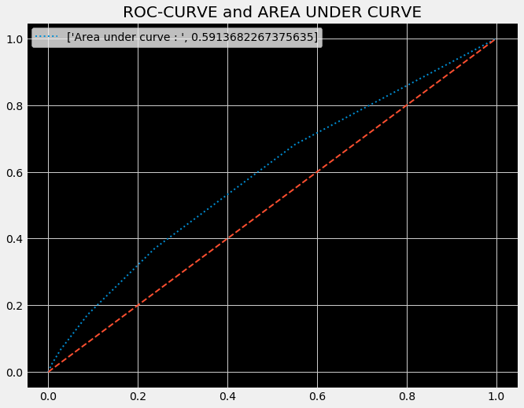

```python
rfc = RandomForestClassifier()
eval_model(rfc, X_train, Y_train, X_test, Y_test, X_train.columns)
```

### 5.3.3 - GradientBoostingClassifier

```
GradientBoostingClassifier(criterion='friedman_mse', init=None,
              learning_rate=0.1, loss='deviance', max_depth=3,
              max_features=None, max_leaf_nodes=None,
              min_impurity_decrease=0.0, min_impurity_split=None,
              min_samples_leaf=1, min_samples_split=2,
              min_weight_fraction_leaf=0.0, n_estimators=100,
              n_iter_no_change=None, presort='auto', random_state=None,
              subsample=1.0, tol=0.0001, validation_fraction=0.1,
              verbose=0, warm_start=False)
Accuracy score:  0.9193684758219245
Recall score:  0.0
Classification report:
               precision    recall  f1-score   support

         0.0       1.00      0.92      0.96     61500
         1.0       0.00      0.00      0.00         2

   micro avg       0.92      0.92      0.92     61502
   macro avg       0.50      0.46      0.48     61502
weighted avg       1.00      0.92      0.96     61502
```

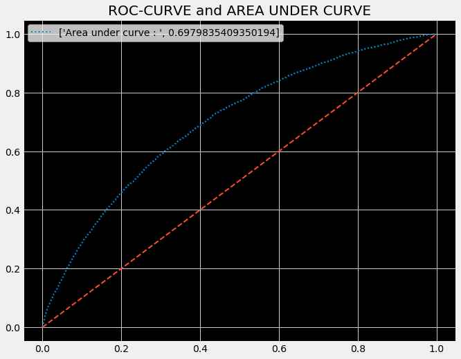

```python
gbc = GradientBoostingClassifier()
eval_model(gbc, X_train, Y_train, X_test, Y_test, X_train.columns)
```

### 5.3.4 - DecisionTreeClassifier

```
DecisionTreeClassifier(class_weight=None, criterion='gini', max_depth=None,
            max_features=None, max_leaf_nodes=None,
            min_impurity_decrease=0.0, min_impurity_split=None,
            min_samples_leaf=1, min_samples_split=2,
            min_weight_fraction_leaf=0.0, presort=False, random_state=None,
            splitter='best')
Accuracy score:  0.8474195961106956
Recall score:  0.11855936584525245
Classification report:
               precision    recall  f1-score   support

         0.0       0.91      0.92      0.92     55699
         1.0       0.14      0.12      0.13      5803

   micro avg       0.85      0.85      0.85     61502
   macro avg       0.52      0.52      0.52     61502
weighted avg       0.84      0.85      0.84     61502
```

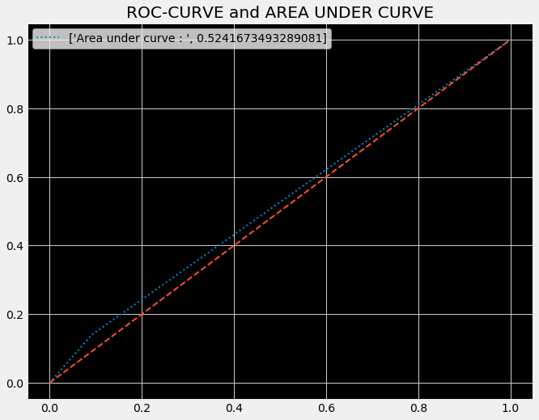

```python
dtc = DecisionTreeClassifier()
eval_model(dtc, X_train, Y_train, X_test, Y_test, X_train.columns)
```

### 5.3.5 - GaussianNB

```
GaussianNB(priors=None, var_smoothing=1e-09)
Accuracy score:  0.9127833241195408
Recall score:  0.1976225854383358
Classification report:
               precision    recall  f1-score   support

         0.0       0.99      0.92      0.95     60829
         1.0       0.03      0.20      0.05       673

   micro avg       0.91      0.91      0.91     61502
   macro avg       0.51      0.56      0.50     61502
weighted avg       0.98      0.91      0.94     61502
```

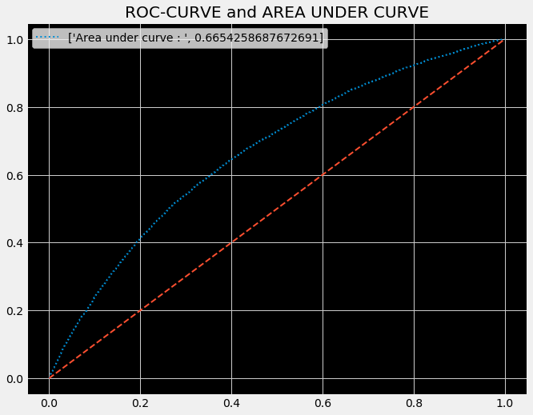

```python
gnb = GaussianNB()
eval_model(gnb, X_train, Y_train, X_test, Y_test, X_train.columns)
```

### 5.3.6 - XGBClassifier

```
XGBClassifier(base_score=0.5, booster='gbtree', colsample_bylevel=1,
       colsample_bynode=1, colsample_bytree=1, gamma=0, learning_rate=0.1,
       max_delta_step=0, max_depth=3, min_child_weight=1, missing=None,
       n_estimators=100, n_jobs=1, nthread=None,
       objective='binary:logistic', random_state=0, reg_alpha=0,
       reg_lambda=1, scale_pos_weight=1, seed=None, silent=None,
       subsample=1, verbosity=1)
Accuracy score:  0.9194009950895906
Recall score:  0.0
Classification report:
               precision    recall  f1-score   support

         0.0       1.00      0.92      0.96     61502
         1.0       0.00      0.00      0.00         0

   micro avg       0.92      0.92      0.92     61502
   macro avg       0.50      0.46      0.48     61502
weighted avg       1.00      0.92      0.96     61502
```

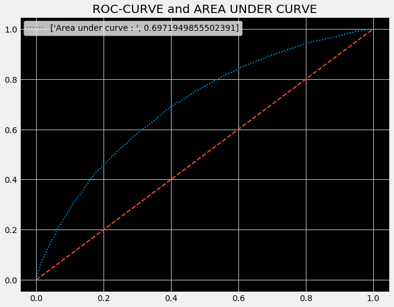

```python
xgb = XGBClassifier()
eval_model(xgb, X_train, Y_train, X_test, Y_test, X_train.columns)
```

### 5.3.7 - LGBMClassifier

```
LGBMClassifier(boosting_type='gbdt', class_weight=None, colsample_bytree=1.0,
        importance_type='split', learning_rate=0.1, max_depth=-1,
        min_child_samples=20, min_child_weight=0.001, min_split_gain=0.0,
        n_estimators=100, n_jobs=-1, num_leaves=31, objective=None,
        random_state=None, reg_alpha=0.0, reg_lambda=0.0, silent=True,
        subsample=1.0, subsample_for_bin=200000, subsample_freq=0)
Accuracy score:  0.9193847354557575
Recall score:  0.0
Classification report:
               precision    recall  f1-score   support

         0.0       1.00      0.92      0.96     61501
         1.0       0.00      0.00      0.00         1

   micro avg       0.92      0.92      0.92     61502
   macro avg       0.50      0.46      0.48     61502
weighted avg       1.00      0.92      0.96     61502
```

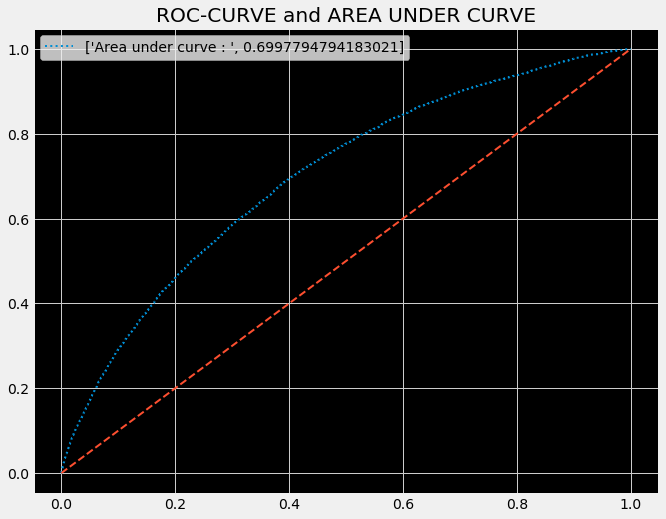

```python
lgbm = LGBMClassifier()
eval_model(lgbm, X_train, Y_train, X_test, Y_test, X_train.columns)
```

```python
del logit
del rfc
del gbc
del dtc
del gnb
del xgb
del lgbm
gc.collect()
```

```
25240
```

# Part 6 - Optimize chosen model

So far, we have used default hyperparameters for all models, including the chosen LGBMClassifier. In this part, we shall tune hyperparameters to optimize the model for the dataset.

## 6.1 Strategy

For this notebook, we shall tune LGBMClassifier with a subset of the data consisting of 20000 rows. Hyperparameter tuning is extremely computationally expensive and working with the full dataset would not be feasible here. However, same idea can be applied to entire dataset, if the notebook runs in a machine with much higher resources (CPU, RAM etc.).

Also, we shall test the tuned model with 6000 rows.

## 6.2 Create training and test data

```python
# Sample 26000 rows (20000 for training, 6000 for testing)
data_set = app_pca_df.sample(n = 26000, random_state = 42)
data_set.shape
```

```
(26000, 41)
```

```python
# Extract the labels
labels = np.array(data_set['TARGET'].astype(np.int32)).reshape((-1, ))
# extract the features
features = data_set.drop(['TARGET'], axis=1)
```

```python
# Split into training and testing data
train_features, test_features, train_labels, test_labels = train_test_split(features, labels, test_size = 6000, random_state = 50)
```

```python
print("Training features shape: ", train_features.shape)
print("Testing features shape: ", test_features.shape)
```

```
Training features shape:  (20000, 40)
Testing features shape:  (6000, 40)
```

```python
del data_set
gc.collect()
```

```
120
```

## 6.3 Cross validation and early stopping

Each combination of hyperparameter values needs to be evaluated. The evaluation **cannot be done using test data**. The model should see test data only once. Therefore, a portion of training data needs to keep aside for validation. This set is called 'validation set'. However, if we use [KFold cross validation](https://scikit-learn.org/stable/modules/generated/sklearn.model_selection.KFold.html), then we don't need to keep separate validation set. The performance of each set of hyperparameters is determined by Receiver Operating Characteristic Area Under the Curve (ROC AUC) from the cross-validation.

In machine learning, **early stopping** is a form of regularization used **to avoid overfitting** when training a learner. Here, early stopping means training until the validation error does not decrease for a specified number of iterations.

We shall use 5-fold validation.

```python
N_FOLDS = 5
MAX_EVALS = 5
```

```python
# Create LGB training and testing dataset
train_set = lgb.Dataset(data = train_features, label = train_labels)
test_set = lgb.Dataset(data = test_features, label = test_labels)
```

## 6.4 Baselining

Let's start with default LGBMClassifier and evaluate this model. We shall **baseline** the result. After hyperparameter tuning, we shall compare output of the tuned model with this baselined result.

```python
# Get default hyperparameters
model = LGBMClassifier()
default_params = model.get_params()

# Remove the number of estimators because we set this to 10000 in the cv call
del default_params['n_estimators']

# Cross validation with early stopping
cv_results = lgb.cv(default_params, train_set, num_boost_round = 10000, early_stopping_rounds = 100,
                    metrics = 'auc', nfold = N_FOLDS, seed = 42)
```

The cv_results is a dictionary with lists for the mean and the standard deviation. The last entry (index of -1) contains best performing score. The length of each list in the dictionary will be the "optimal" number of estimators to train.

```python
print('The best ROC AUC vslue: {:.5f}, with standard deviation of {:.5f}.'.format(cv_results['auc-mean'][-1], cv_results['auc-stdv'][-1]))
print('Optimal number of estimators: {}.'.format(len(cv_results['auc-mean'])))
```

```
The best ROC AUC vslue: 0.67697, with standard deviation of 0.01934.
Optimal number of estimators: 57.
```

```python
# Optimal number of esimators found in cv
model.n_estimators = len(cv_results['auc-mean'])

# Train and make predicions with model
model.fit(train_features, train_labels)
preds = model.predict_proba(test_features)[:, 1]
baseline_auc = roc_auc_score(test_labels, preds)

print('ROC AUC score of the baseline model on test set: {:.5f}'.format(baseline_auc))
```

```
ROC AUC score of the baseline model on test set: 0.66728
```

This is the baseline score before hyperparameter tuning.

```python
del cv_results
del model
del preds
del baseline_auc
gc.collect()
```

```
426
```

## 6.5 Hyperparameter Tuning

We need to define following four aspects of this hyperparameter tuning:

- **Objective function**: a function that takes in hyperparameters and returns a score. Objective is either to minimize or maximize this score
- **Domain**: the set of hyperparameters whose optimum values we want to search
- **Algorithm**: method for selecting the next set of hyperparameters to evaluate in the objective function
- **Results history**: data structure containing each set of hyperparameters and corresponding score from the objective function

### 6.5.1 Objective function

Let's first define the objective function. This objective function will be used in grid search and will return cross-validation ROC AUC score from the set of hyperparameters.

- **Score to be used**: ROC AUC
- **Objective**: maximize this ROC AUC score

```python
def objective(hyperparameters, iteration):
    '''
    Objective function for grid search.
    Returns the cross validation score from a set of hyperparameters.
    INPUT:
    hyperparameters: hyperparameters of the model
    iteration: number of the iteration
    OUTPUT:
    Array of ROC AUC score, hyperparameters and iteration number
    '''

    # Number of estimators will be found using early stopping
    if 'n_estimators' in hyperparameters.keys():
        del hyperparameters['n_estimators']

    # Perform n_folds cross validation
    cv_results = lgb.cv(hyperparameters, train_set, num_boost_round = 10000, nfold = N_FOLDS,
                        early_stopping_rounds = 100, metrics = 'auc', seed = 42)

    # results to retun
    score = cv_results['auc-mean'][-1]
    hyperparameters['n_estimators'] = len(cv_results['auc-mean'])

    return [score, hyperparameters, iteration]
```

### 6.5.2 Domain

Now, we shall define hyperparameter-grid of **LGBMClassifier** that we shall tune. This [documentation](https://lightgbm.readthedocs.io/en/latest/Parameters.html) explains each hyperparameter.

Let's see the list of hyperparameters of the default model.

```python
model = lgb.LGBMModel()
model.get_params()
```

```
{'boosting_type': 'gbdt',
 'class_weight': None,
 'colsample_bytree': 1.0,
 'importance_type': 'split',
 'learning_rate': 0.1,
 'max_depth': -1,
 'min_child_samples': 20,
 'min_child_weight': 0.001,
 'min_split_gain': 0.0,
 'n_estimators': 100,
 'n_jobs': -1,
 'num_leaves': 31,
 'objective': None,
 'random_state': None,
 'reg_alpha': 0.0,
 'reg_lambda': 0.0,
 'silent': True,
 'subsample': 1.0,
 'subsample_for_bin': 200000,
 'subsample_freq': 0}
```

```python
gc.collect()
```

```
60
```

Let's now, define the hyperparameter-grid containing ten hyperparameters.

```python
# Hyperparameter grid
param_grid = {
    'boosting_type': ['gbdt', 'goss', 'dart'],
    'num_leaves': list(range(20, 150)),
    'learning_rate': list(np.logspace(np.log10(0.005), np.log10(0.5), base = 10, num = 1000)),
    'subsample_for_bin': list(range(20000, 300000)),
    'min_child_samples': list(range(5, 20, 500)),
    'reg_alpha': list(np.linspace(0, 1)),
    'reg_lambda': list(np.linspace(0, 1)),
    'colsample_bytree': list(np.linspace(0.6, 1, 10)),
    'subsample': list(np.linspace(0.5, 1, 100)),
    'is_unbalance': [True, False]
}
```

### 6.5.3 Algorithm

The process of choosing the set of hyperparameter depends on the algorithm. In this notebook, following two algorithms will be used:

- **Grid search**: The 'domain' contains the hyperparameter-grid. The grid search method tries all combinations of values in the grid, evaluates each combination of hyperparameter with the objective function and records the set along with the score in the 'record history'. The 'record history' is sorted according to the score.
  - Limitations:
    - Grid search is extremely computationally expensive because we have to perform cross validation with every single combination of hyperparameters in the grid.
    - Result depends on the choice of the grid. The algorithm only chooses best combination of values from the set of available values in the hyperparameter-grid.
- **Random search**: This algorithm differs from grid-search only in the method of choosing the combination of hyperparameters. As the name suggests, this algorithm randomly selects the next set of hyperparameters from the grid. This is uninformed search which means next selection of hyperparameters does not rely on past evaluation results. Once a set of hyperparameters is chosen, then just like grid search, that combination of hyperparameters is evaluated with the objective function and evaluation is recorded in the 'record history'. The 'record history' is sorted according to the score.

#### 6.5.3.1 Grid search

Let's implement grid search algorithm. In the case of grid search, we input the domain and the algorithm selects the next value for each hyperparameter in an ordered sequence. The only requirement of grid search is that it tries every combination in a grid once (and only once).

Usually, in grid search, we do not limit the number of evaluations. The number of evaluations is set by the total combinations in the hyperparameter grid. However, let's see the number of combinations we have.

```python
com = 1
for x in param_grid.values():
    com *= len(x)
print('There are {} combinations in the hyperparameter grid.'.format(com))
```

```
There are 546000000000000000 combinations in the hyperparameter grid.
```

Evidently, if we don't 'hard-stop' our grid search with something like maximum number of evaluations, this grid search **will take years** to test each combination with cross-validation.

```python
def grid_search(param_grid, max_evals = MAX_EVALS):
    '''
    Grid search algorithm (with limit on max evals)
    INPUT:
    param_grid: The grid of hyperparameters
    max_evals: maximum number of evaluations
    OUTPUT:
    results: results history
    '''

    # Dataframe to store results
    results = pd.DataFrame(columns = ['score', 'params', 'iteration'],
                              index = list(range(max_evals)))

    keys, values = zip(*param_grid.items())

    i = 0

    # Iterate through every possible combination of hyperparameters
    for v in itertools.product(*values):

        # Create a hyperparameter dictionary
        hyperparameters = dict(zip(keys, v))

        # Set the subsample ratio accounting for boosting type
        hyperparameters['subsample'] = 1.0 if hyperparameters['boosting_type'] == 'goss' else hyperparameters['subsample']

        # Evalute the hyperparameters
        eval_results = objective(hyperparameters, i)

        results.loc[i, :] = eval_results

        i += 1

        # Normally would not limit iterations
        if (i >= max_evals):
            break

    # Sort with best score on top
    results.sort_values('score', ascending = False, inplace = True)
    results.reset_index(inplace = True)

    return results
```

#### 6.5.3.2 Random search

Let's implement random search algorithm. Random search is always run with a limit on the number of search iterations.

```python
def random_search(param_grid, max_evals = MAX_EVALS):
    '''
    Random search for hyperparameter optimization (with limit on max evals)
    INPUT:
    param_grid: The grid of hyperparameters
    max_evals: maximum number of evaluations
    OUTPUT:
    results: results history
    '''

    # Dataframe for results
    results = pd.DataFrame(columns = ['score', 'params', 'iteration'],
                                  index = list(range(MAX_EVALS)))

    # Keep searching until reach max evaluations
    for i in range(max_evals):

        # Choose random hyperparameters
        hyperparameters = {k: random.sample(v, 1)[0] for k, v in param_grid.items()}
        hyperparameters['subsample'] = 1.0 if hyperparameters['boosting_type'] == 'goss' else hyperparameters['subsample']

        # Evaluate randomly selected hyperparameters
        eval_results = objective(hyperparameters, i)

        results.loc[i, :] = eval_results

    # Sort with best score on top
    results.sort_values('score', ascending = False, inplace = True)
    results.reset_index(inplace = True)

    return results
```

### 6.5.4 Results history

The results history is a data structure that contains the collection (that means, history) of results. Each result has following columns: 'score', 'params', 'iteration'. Both grid search and random search will sort result history according to the score, in descending order.

#### 6.5.4.1 Perform grid search

```python
grid_results = grid_search(param_grid)

print('The best validation score was {:.5f}'.format(grid_results.loc[0, 'score']))
print('\nThe best hyperparameters were:')
pprint.pprint(grid_results.loc[0, 'params'])
```

```
The best validation score was 0.69284

The best hyperparameters were:
{'boosting_type': 'gbdt',
 'colsample_bytree': 0.6,
 'is_unbalance': True,
 'learning_rate': 0.004999999999999999,
 'min_child_samples': 5,
 'n_estimators': 1321,
 'num_leaves': 20,
 'reg_alpha': 0.0,
 'reg_lambda': 0.0,
 'subsample': 0.5,
 'subsample_for_bin': 20000}
```

To get a sense of how grid search works, we can look at the progression of hyperparameters that were evaluated

```python
pd.options.display.max_colwidth = 1000
grid_results
```

|  | index | score | params | iteration |
| --- | --- | --- | --- | --- |
| 0 | 0 | 0.692836 | {'boosting_type': 'gbdt', 'num_leaves': 20, 'learning_rate': 0.004999999999999999, 'subsample_for_bin': 20000, 'min_child_samples': 5, 'reg_alpha': 0.0, 'reg_lambda': 0.0, 'colsample_bytree': 0.6, 'su… | 0 |
| 1 | 1 | 0.692836 | {'boosting_type': 'gbdt', 'num_leaves': 20, 'learning_rate': 0.004999999999999999, 'subsample_for_bin': 20000, 'min_child_samples': 5, 'reg_alpha': 0.0, 'reg_lambda': 0.0, 'colsample_bytree': 0.6, 'su… | 1 |
| 2 | 2 | 0.692836 | {'boosting_type': 'gbdt', 'num_leaves': 20, 'learning_rate': 0.004999999999999999, 'subsample_for_bin': 20000, 'min_child_samples': 5, 'reg_alpha': 0.0, 'reg_lambda': 0.0, 'colsample_bytree': 0.6, 'su… | 2 |
| 3 | 3 | 0.692836 | {'boosting_type': 'gbdt', 'num_leaves': 20, 'learning_rate': 0.004999999999999999, 'subsample_for_bin': 20000, 'min_child_samples': 5, 'reg_alpha': 0.0, 'reg_lambda': 0.0, 'colsample_bytree': 0.6, 'su… | 3 |
| 4 | 4 | 0.692836 | {'boosting_type': 'gbdt', 'num_leaves': 20, 'learning_rate': 0.004999999999999999, 'subsample_for_bin': 20000, 'min_child_samples': 5, 'reg_alpha': 0.0, 'reg_lambda': 0.0, 'colsample_bytree': 0.6, 'su… | 4 |

Only values of 'subsample' and 'is_unbalance' hyperparameters changed during these limited runs. In fact, effect of changing these hyperparameters is so small that validation score literally didn't change across iterations.

#### Determine ROC AUC score of the tuned model

Now, since we have the best hyperparameters, we can evaluate them on our "test" data. This "test" data has been created in section 6.2.

```python
# Get best hyperparameters as determined by grid search
grid_search_params = grid_results.loc[0, 'params']

# Create model with best hyperparameters
model = LGBMClassifier(**grid_search_params, random_state=42)
print('Optimized model created.')

# fit with training data
model.fit(train_features, train_labels)
print('Fitted with training data.')

# predict with test features
pred_labels = model.predict_proba(test_features)[:, 1]
print('Predicted on test features.')

# compute and print ROC AUC score
score = roc_auc_score(test_labels, pred_labels)
print('After tuning, ROC AUC score of the model on the test set, is {:.5f}.'.format(score))
```

```
Optimized model created.
Fitted with training data.
Predicted on test features.
After tuning, ROC AUC score of the model on the test set, is 0.67869.
```

#### Testing the model over multiple sets of data

In this section, we shall split data into multiple sets. For each set, we shall compute ROC AUC score of the model. Then, we shall see those scores to assess robustness of the model.

Let us first define a function that can test the model over multiple folds of data. This function we shall reuse later during optimization using random search algorithm.

```python
def kfold_lightgbm(train_df, train_target, clf, num_folds=5):
    '''
    This function splits data into multiple folds,
    compute ROC AUC score of the model for each set, and,
    print and return the scores.
    INPUT:
    train_df: input features of training data
    train_target: output labels of training data
    clf: the model to be tested
    num_folds: number of sets the data should be split into. Default is 5.
    OUTPUT:
    scores: the dataframe containing scores
    '''
    print("Starting LightGBM. Input data shape: {}".format(train_df.shape))
    # Cross validation model
    folds = KFold(n_splits=num_folds, shuffle=True, random_state=47)
    # Create arrays and dataframes to store results
    oof_preds = np.zeros(train_df.shape[0])
    scores = pd.DataFrame(columns=['n_fold', 'Score'])

    for n_fold, (train_idx, valid_idx) in enumerate(folds.split(train_df, train_target)):
        train_x, train_y = train_df.iloc[train_idx], train_target.iloc[train_idx]
        valid_x, valid_y = train_df.iloc[valid_idx], train_target.iloc[valid_idx]

        clf.fit(train_x, train_y, eval_set=[(train_x, train_y), (valid_x, valid_y)],
            eval_metric='auc', verbose=1000, early_stopping_rounds=300)

        oof_preds[valid_idx] = clf.predict_proba(valid_x, num_iteration=clf.best_iteration_)[:, 1]
        score = roc_auc_score(valid_y, oof_preds[valid_idx])
        n_fold_num = n_fold + 1
        #print('Fold %2d AUC : %.6f' % (n_fold_num, score))
        #scores.append(score)
        scores = scores.append({'n_fold': n_fold_num, 'Score': score}, ignore_index=True)
        del train_x, train_y, valid_x, valid_y
        gc.collect()

    return scores
```

```python
train_labels_df = pd.DataFrame(train_labels, columns=['TARGET'])
train_labels_df.head()
```

|  | TARGET |
| --- | --- |
| 0 | 0 |
| 1 | 0 |
| 2 | 0 |
| 3 | 0 |
| 4 | 0 |

```python
scores = kfold_lightgbm(train_features, train_labels_df, model)
```

[output not shown]

```python
scores
```

[output not shown]

```python
mean_score = scores['Score'].mean()
var_score = scores['Score'].var()
print('Mean AUC score %.6f' % mean_score)
print('Variance of AUC score %.6f' % var_score)
```

```
Mean AUC score 0.680479
Variance of AUC score 0.000613
```

```python
gc.collect()
```

```
60
```

#### 6.5.4.2 Perform random search

```python
random_results = random_search(param_grid)

print('The best validation score was {:.5f}'.format(random_results.loc[0, 'score']))
print('\nThe best hyperparameters were:')
pprint.pprint(random_results.loc[0, 'params'])
```

```
The best validation score was 0.68067

The best hyperparameters were:
{'boosting_type': 'goss',
 'colsample_bytree': 0.6444444444444444,
 'is_unbalance': False,
 'learning_rate': 0.005929855061688347,
 'min_child_samples': 5,
 'n_estimators': 143,
 'num_leaves': 144,
 'reg_alpha': 0.836734693877551,
 'reg_lambda': 0.4081632653061224,
 'subsample': 1.0,
 'subsample_for_bin': 44005}
```

Let us now see the progression of hyperparameters that were evaluated, in case of random search

```python
pd.options.display.max_colwidth = 1000
random_results
```

|  | index | score | params | iteration |
| --- | --- | --- | --- | --- |
| 0 | 2 | 0.680674 | {'boosting_type': 'goss', 'num_leaves': 144, 'learning_rate': 0.005929855061688347, 'subsample_for_bin': 44005, 'min_child_samples': 5, 'reg_alpha': 0.836734693877551, 'reg_lambda': 0.4081632653061224… | 2 |
| 1 | 4 | 0.669605 | {'boosting_type': 'goss', 'num_leaves': 63, 'learning_rate': 0.016962916913704967, 'subsample_for_bin': 122225, 'min_child_samples': 5, 'reg_alpha': 0.3469387755102041, 'reg_lambda': 0.693877551020408… | 4 |
| 2 | 3 | 0.667906 | {'boosting_type': 'gbdt', 'num_leaves': 145, 'learning_rate': 0.062239357309395296, 'subsample_for_bin': 62301, 'min_child_samples': 5, 'reg_alpha': 0.7755102040816326, 'reg_lambda': 0.734693877551020… | 3 |
| 3 | 0 | 0.62677 | {'boosting_type': 'goss', 'num_leaves': 77, 'learning_rate': 0.43341899650098886, 'subsample_for_bin': 282727, 'min_child_samples': 5, 'reg_alpha': 0.6938775510204082, 'reg_lambda': 0.7755102040816326… | 0 |
| 4 | 1 | 0.619812 | {'boosting_type': 'goss', 'num_leaves': 114, 'learning_rate': 0.40260198354127363, 'subsample_for_bin': 228113, 'min_child_samples': 5, 'reg_alpha': 0.32653061224489793, 'reg_lambda': 0.85714285714285… | 1 |

This time, we can see much better variations of hyperparameters' values and progression of score, in comparison with what we have seen in grid search.

#### Determine ROC AUC score of the tuned model

As in case before with grid search, we shall evaluate the model on small "test" data, as created in section 6.2.

```python
# Get best hyperparameters as determined by grid search
random_search_params = random_results.loc[0, 'params']

# Create model with best hyperparameters
model = LGBMClassifier(**random_search_params, random_state=42)
print('Optimized model created.')

# fit with training data
model.fit(train_features, train_labels)
print('Fitted with training data.')

# predict with test features
pred_labels = model.predict_proba(test_features)[:, 1]
print('Predicted on test features.')

# compute and print ROC AUC score
score = roc_auc_score(test_labels, pred_labels)
print('After tuning, ROC AUC score of the model on the test set, is {:.5f}.'.format(score))
```

```
Optimized model created.
Fitted with training data.
Predicted on test features.
After tuning, ROC AUC score of the model on the test set, is 0.67717.
```

#### Testing the model over multiple sets of data

In this section, we shall split data into multiple sets. For each set, we shall compute ROC AUC score of the model. Then, we shall see those scores to assess robustness of the model.

```python
scores = kfold_lightgbm(train_features, train_labels_df, model)
```

```
Starting LightGBM. Input data shape: (20000, 40)
Training until validation scores don't improve for 300 rounds
Did not meet early stopping. Best iteration is:
[143]	training's auc: 0.972087	training's binary_logloss: 0.204683	valid_1's auc: 0.683757	valid_1's binary_logloss: 0.271723
Training until validation scores don't improve for 300 rounds
Did not meet early stopping. Best iteration is:
[143]	training's auc: 0.973733	training's binary_logloss: 0.207381	valid_1's auc: 0.697466	valid_1's binary_logloss: 0.257439
Training until validation scores don't improve for 300 rounds
Did not meet early stopping. Best iteration is:
[143]	training's auc: 0.97122	training's binary_logloss: 0.201839	valid_1's auc: 0.648421	valid_1's binary_logloss: 0.280352
Training until validation scores don't improve for 300 rounds
Did not meet early stopping. Best iteration is:
[143]	training's auc: 0.975595	training's binary_logloss: 0.207413	valid_1's auc: 0.709354	valid_1's binary_logloss: 0.260548
Training until validation scores don't improve for 300 rounds
Did not meet early stopping. Best iteration is:
[143]	training's auc: 0.975757	training's binary_logloss: 0.200585	valid_1's auc: 0.663399	valid_1's binary_logloss: 0.28467
```

```python
scores
```

|  | n_fold | Score |
| --- | --- | --- |
| 0 | 1.0 | 0.683757 |
| 1 | 2.0 | 0.697466 |
| 2 | 3.0 | 0.648421 |
| 3 | 4.0 | 0.709354 |
| 4 | 5.0 | 0.663399 |

```python
mean_score = scores['Score'].mean()
var_score = scores['Score'].var()
print('Mean AUC score %.6f' % mean_score)
print('Variance of AUC score %.6f' % var_score)
```

```
Mean AUC score 0.680479
Variance of AUC score 0.000613
```

### 6.5.5 Observations

We have observed that the final LGBMClaissifer model is quite robust. We have tested the model over 5 sets of data. We received mean ROC AUC score as 0.680479 with variance of 0.000613.

```python
gc.collect()
```

```
60
```

## 6.6 Conclusion on model optimization

- In this notebook, two strategies were demonstrated, which are **grid search** and **random search**, to select best combination of hyperparameters for LGBMClassifier.
- In order to **limit consumption of hardware resources**:
  - only a small subset of training and test data have been used to demonstrate model tuning. This has been explained in sections 6.1 and 6.2. In reality, entire training and test data can be used.
  - Grid search and random search have been evaluated only 5 times. In reality, higher number of iterations can be tried.
  - Only a small subset of hyperparameters and a limited number of their values have been chosen to create hyperparameter-grid, in section 6.5.2. In reality, we can include more hyperparameters and more values. However, computational complexity polynomially increases with the increase in dimension of hyperparameter-grid.
- We have observed only marginal improvement in ROC AUC metric, after hyperparameter tuning. This is mainly attributed to following reasons:
  - Small set of data chosen
  - small set of hyperparameters chosen
  - Small number of iterations in grid search and random search
- We have tested the model on different sets of data. We have found that the model is quite stable.
- I haven't used [GridSearchCV](https://scikit-learn.org/stable/modules/generated/sklearn.model_selection.GridSearchCV.html) or [RandomizedSearchCV](https://scikit-learn.org/stable/modules/generated/sklearn.model_selection.RandomizedSearchCV.html) for following reasons:
  - In our objective function, I have used KFold cross validation, as implemented by LightGBM cross validation function, cv. Here, I could use **early stopping** which is critical for training a GBM.
  - Both of GridSearchCV and RandomizedSearchCV are computationally intensive. Their parallel processing and in-memory operations require high CPU and RAM.

# Summary and Reflection

In this notebook, we have studied various factors related to a financial loan, which governs the risk associated with the repayment in time.

We have analyzed the data, rectified few anomalies, imputed missing values, encoded categorical features and finally reduced the dimension of the data using PCA. We also have observed 'class imbalance problem' related to the data.

We have evaluated several classification models and have chosen light GBM classifier for classifying the defaulting risk. We have also chosen ROC AUC metric for measuring the performance of the models. Chosen model has scored around 0.7 which is not that bad. Mostly, it was the data which need to be more balanced across output labels.

Now, let's see what is AUC score 0.7 means.

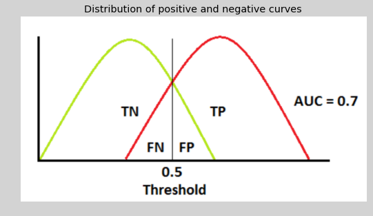

```python
image = np.array(Image.open(r"images/AUC_interpretation.png"))
fig = plt.figure(figsize=(8,5))
plt.imshow(image,interpolation="bilinear")
plt.axis("off")
fig.set_facecolor("lightgrey")
plt.title("Distribution of positive and negative curves")
plt.show()
```

Red distribution curve is of the positive class (borrower may default) and green distribution curve is of negative class (borrower will repay in time).

As we know, AUC represents degree or measure of separability. Higher the AUC, better the model is at predicting 0s as 0s and 1s as 1s.

When two distributions overlap, type 1 and type 2 errors are introduced. Depending upon the threshold, we can minimize or maximize them. When AUC is 0.7, it means there is 70% chance that model will be able to distinguish between positive class and negative class.

This means, our model will be correct on 70% times in identifying a borrower having risk of defaulting a loan.

Finally, we have demonstrated how chosen model can be tuned to optimize its performance. Though, we have some limitations in resources, but tuning processes as shown, can be followed to optimize LGBMClassifier in real-world scenario.

## Key learnings

- Finding right data is key to success of any datascience problem.
- Finding right model is next important aspect.
- Companies investing on datascience should spend on proper infrastructure, data governance and data strategies

## Improvement

In this section, let us discuss few aspects of the implementation that can be improved.

### Improvement 1 - imputing missing values

In case of imputing missing values in section 4.1, NaN were filled with 'median' values. 'Median' works well when the data is sorted. A better approach will certainly be using a supervised learning model to 'predict' the NaN values.

However, imputation of data means introduction of data by data analysis. This will always add some bias, however negligible its effect is. Certain model like [XGBoost](https://xgboost.readthedocs.io/en/latest/python/python_api.html) can handle NaN in data.

### Improvement 2 - selection of hyperparameters for LGBMClassifier

In section 6.5.2 we have selected a subset of hyperparameters. In sections 6.5.3 and 6.5.4, we have performed grid search and random search to select best set values on the hyperparameters.

Smarter technique can be combining random search and grid search as follows:

- Use random search with large hyperparameter grid
- Use the results of random search to build a focused hyperparameter grid around the best performing hyperparameter values
- Run grid search on this reduced hyperparameter grid. We can limit number of iterations or not, depending on hardware resources available or maximum time allowed.